# Final_Project

CMSC320 Final Project: Spotify Data Analysis for Germany and the U.S

Created by Michael Woods

**Introduction**

Spotify is a service I use all the time, and I've noticed that I often listen to German Music. That got me thinking; just how different is the music in germany and the U.S?

First, let's go over the importance of music in germany. Germany served as the source of many popular genres today, such as Classical Music, Electronic and more. They still serve as one of the major musical industries in the world, and are known for their experimental music.

The United States in another one of the largest musical industries in the world, with their influence spreading throughout the globe. Now, I tend to prefer german music, but this begs the question; is here really a difference in the music popular in Germany and the United States? I will examine this question from looking at the top 200 for each country from 2017 onwards using Spotipy. Spotipy is a library that allows me to extract music features; The features I will be looking at are danceability, energy, key, loudness, mode, speechines, acousticness, instrumentalness, liveliness, valence and tempo. I will also be comparing the popular genres of the two countries, and finally I will create a classifer to see if a given song would most likely be in the top 10 in Germany or the United States.

**Scraping the Data**

```python
import spotipy
import pandas as pd
import matplotlib.pyplot as plt
import numpy as np
from spotipy.oauth2 import SpotifyClientCredentials
cid = "58ff3ad8fc2446669ee16d1a75185ba8"
secret = "85504b94651641a7ad56602bfac5eab9"
client_credentials_managerMan = SpotifyClientCredentials(client_id=cid, client_secret=secret)
sp = spotipy.Spotify(client_credentials_manager = client_credentials_managerMan)
```

```python
#chart I am using
spotifySongs = pd.read_csv("charts.csv")
SpotifyDataSong = pd.DataFrame(spotifySongs)

#getting rid of repeats
newEntry_df = spotifySongs[spotifySongs["trend"] == "NEW_ENTRY"]
#getting songs in the US region
america_df = newEntry_df[spotifySongs["region"] == "United States"]
#getting songs in German Region
german_df = newEntry_df[spotifySongs["region"] == "Germany"]
#making sure that songs are rank 10 or less
america_df = america_df[america_df["rank"] <= 10]
german_df = german_df[german_df["rank"] <= 10]
spotifySongs = spotifySongs[spotifySongs["trend"] == "NEW_ENTRY"]
```

```python
#getting the top 200 songs; the data set also includes top50, and I want as much data as possible so I am going with top200
america_df = america_df[america_df["chart"] == "top200"]
germany_df = german_df[german_df["chart"] == "top200"]
```

```python
#getting the data
def getData(region_df):
    #initializing data frame with url
    element = region_df.head(1)["url"]
    firstTrack = sp.audio_features(element)
    #sp.audio_features returns an array of 1 element
    print(firstTrack[0].keys())
    df = pd.DataFrame(columns = firstTrack[0].keys())

    for index,element in region_df.iterrows():
        url = element["url"]
        rank = element["rank"]
        region = element["region"]
        chart = element["chart"]
        trend = element["trend"]
        streams = element["streams"]
        artist =  element["artist"]
        title =  element["title"]
        date =  element["date"]
        mytrack = sp.audio_features(url)[0]
        df2 = pd.DataFrame(mytrack, index=[0])

        #pd.concat([element, df2])
        #df.concat(e
        df2["rank"] = rank
        df2["artist"] = artist
        df2["title"] = title
        df2["date"] = date
        df2["chart"] = chart
        df2["trend"] = trend
        df2["streams"] = streams
        df2["region"] = region
        df = df.append(df2, ignore_index = True)

    return df
```

```python
#since my dataset does not have the genre for the uri, I
#took the liberty of collecting the data
def get_genre(df):

    for index,element in df.iterrows():
        #url = element["url"]
        artistName = element["artist"]
        result = sp.search(artistName)
        track = result['tracks']['items'][0]
        artist = sp.artist(track["artists"][0]["external_urls"]["spotify"])

        if (artist["genres"]):
            genre = artist["genres"][0]
            if (len(genre) >=3):
                if ("pop" in genre):
                    genre = "pop"
                elif ("rock" in genre):
                    genre = "rock"
                elif ("rap" in genre):
                    genre = "rap"
                elif ("metal" in genre):
                    genre = "rap"
                elif ("country" in genre):
                    genre = "rap"
                elif ("rap" in genre):
                    genre = "rap"
                elif ("electronic" in genre):
                    genre = "electronic"
                elif ("hop" in genre):
                    genre = "hip hop"
            df.iloc[index, df.columns.get_loc('genre')] = genre
```

```python
#getting the data
america_df_final= getData(america_df)
germany_df_final = getData(german_df)
```

```python
#here, I am grabbing 500 samples at most so I can make this nonbiase
america_df_final = america_df_final.sample(500)
germany_df_final = germany_df_final.sample(500)
```

```python
#the following was done for convience so I didn't have to call getData evertime I modified the data frame
compression_opts = dict(method='zip',
                        archive_name='german_gen.csv')
germany_df_final.to_csv('german.zip', index=False,
          compression=compression_opts)

compression_opts2 = dict(method='zip',
                        archive_name='america_gen.csv')

america_df_final.to_csv('america.zip', index=False,
          compression=compression_opts2)
```

```python
combined = germany_df_final.append(america_df_final)
```

```python
compression_opts3 = dict(method='zip',
                        archive_name='combined.csv')
combined.to_csv('combined.zip', index=False,   compression=compression_opts)
```

**Comparing the Features betweeen Germany and the U.S using violin plots**

Here, I will be plotting the features of the songs, to see if the popularity of a song is affected by particular features. Since we are looking at the top 10 songs, technically all of these songs are popular, but there is still variablity in the top 10. I will be focusing on the differences between Germany and the U.S.

```python
#normalize the data for the scatter plot
def NormalizeData(data):
    return (data - np.min(data)) / (np.max(data) - np.min(data))
```

```python
#9 lines
from sklearn import linear_model
from sklearn import preprocessing
import numpy as np
import seaborn as sns
x_array = np.array([2,3,5,6,7,4,8,7,6])
normalized_arr = preprocessing.normalize([x_array])
import statsmodels.formula.api as sm

#plot the data
def plot(df, name, p1):
    #here I put a "rank2" so the higher values will be on the right for the scatter plot
    df["rank2"] = df["rank"] * -1 + 10
    #print(df [df["rank2"] < 2])
    standardized = NormalizeData(df["rank2"]).values
    standardized = df["rank2"].values
    Y = np.asarray(standardized).reshape(-1,1)
    if (p1 == "danceability"):
        X = np.array(df["danceability"].values).reshape(-1,1)
    elif (p1 == "energy"):
        X = np.array(df["energy"].values).reshape(-1,1)
    elif (p1 == "loudness"):
        X = np.array(df["loudness"].values).reshape(-1,1)

    elif (p1 == "instrumentalness"):
        X = np.array(df["loudness"].values).reshape(-1,1)
    elif (p1 == "speechiness"):
        X = np.array(df["speechiness"].values).reshape(-1,1)
    elif (p1 == "acousticness"):
        X = np.array(df["acousticness"].values).reshape(-1,1)
    elif (p1 == "valence"):
        X = np.array(df["valence"].values).reshape(-1,1)
    elif (p1 == "tempo"):
        X = np.array(df["tempo"].values).reshape(-1,1)

    elif (p1 == "liveness"):
        X = np.array(df["liveness"].values).reshape(-1,1)
    else:
        X = np.array(df["danceability"].values).reshape(-1,1)

    plt.scatter(Y,X)
    #plt.plot(X, model.predict(X), color = "red")
    plt.title(name)
    plt.show()
```

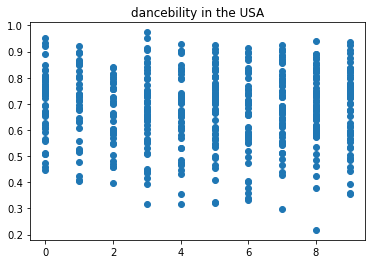

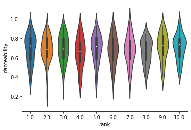

```python
germany_df_final = pd.read_csv("german_gen.csv")
america_df_final = pd.read_csv("america_gen.csv")

plot(america_df_final, "dancebility in the USA","danceability")
america_df_copy = america_df_final.copy()
sns.violinplot(x= "rank", y = "danceability", data = america_df_final)
```

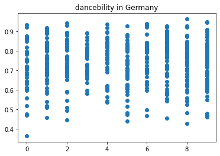

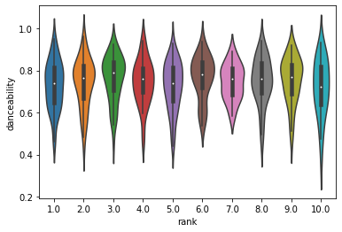

```python
plot(germany_df_final, "dancebility in Germany","danceability")
sns.violinplot(x= "rank", y = "danceability", data = germany_df_final)
```

[figure not shown]

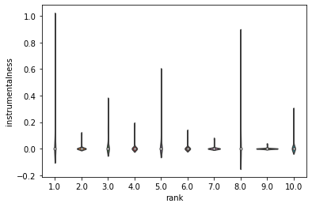

```python
#comparing instrumentalness in Germany and America
plot(america_df_final, "instrumentalness in USA","instrumentalness")
sns.violinplot(x= "rank", y = "instrumentalness", data = america_df_final)
```

[figure not shown]

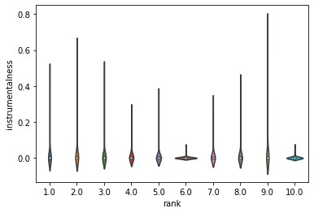

```python
plot(germany_df_final, "instrumentalness in Germany","instrumentalness")
sns.violinplot(x= "rank", y = "instrumentalness", data = germany_df_final)
```

With regard to Instrumentlness(predicts whetehr track cotains no vocals), both the US and Germany are very similiar. What this means is that the vast majority of songs contain some words, or lyrics. This makes sense, considering most popular songs are sure to inlude lyrics. This is most likely because songs with lyrics tend to be more catchy, and for a song to be popular, it should be catchy.

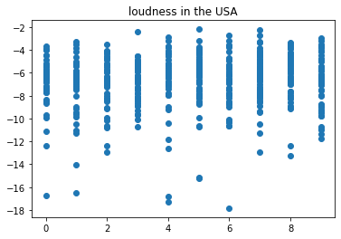

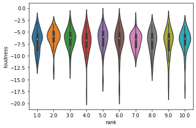

```python
#comparing loudness in USA and Germany
plot(america_df_final, "loudness in the USA","loudness")
sns.violinplot(x= "rank", y = "loudness", data = america_df_final)
```

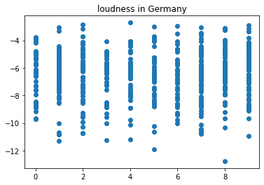

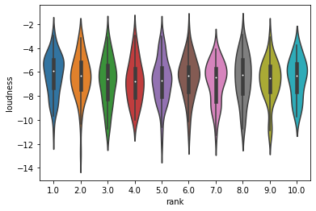

```python
plot(germany_df_final, "loudness in Germany","loudness")
sns.violinplot(x= "rank", y = "loudness", data = germany_df_final)
```

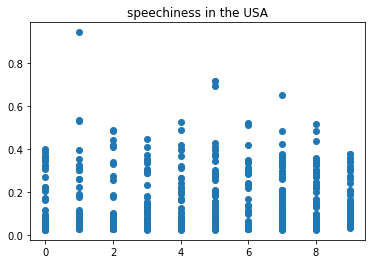

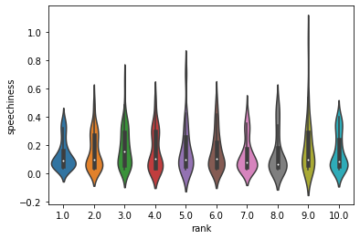

```python
#comparing speechiness in USA and Germany
plot(america_df_final, "speechiness in the USA","speechiness")
sns.violinplot(x= "rank", y = "speechiness", data = america_df_final)
```

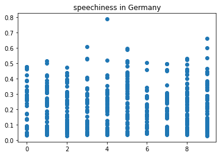

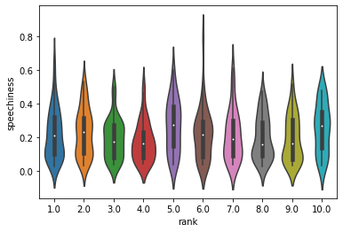

```python
plot(germany_df_final, "speechiness in Germany","speechiness")
sns.violinplot(x= "rank", y = "speechiness", data = germany_df_final)
```

Now, taking a look at speechiness, which detects the precence of spoken words in a track, and the more speechlike the words, the higher the value. Something like a podcast would have a higher speechiness value, and usually songs have a lower speechiness value. Germany had a higher average level of speechiness; this is perhaps because of the dialect of the germans, where there voice does not change as much when they sing compared to America. Rap is a good example of a genre which leans towards higher speechiness values, depending on whether the voice is distorted or changed at all. So, overall it seems as though Germany enjoys more spoken words in their tracks. Overall, the US is much more skewed towards lower speechiness values.

[figure not shown]

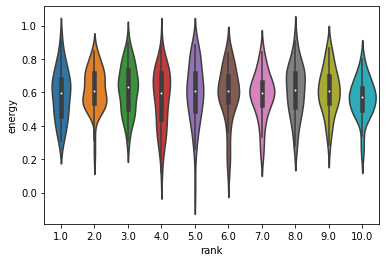

```python
plot(america_df_final, "energy in the USA","acousticness")
sns.violinplot(x= "rank", y = "energy", data = america_df_final)
```

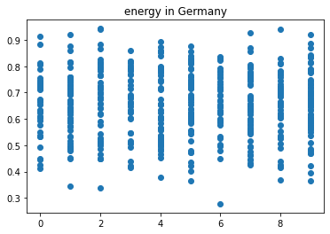

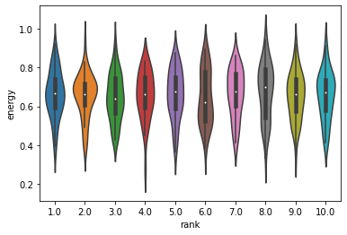

```python
plot(germany_df_final, "energy in Germany","energy")
sns.violinplot(x= "rank", y = "energy", data = germany_df_final)
```

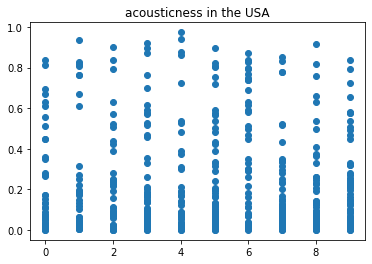

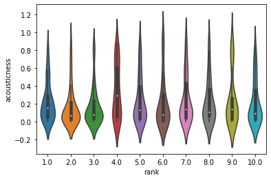

```python
#comparing acousticness in USA and Germany
plot(america_df_final, "acousticness in the USA","acousticness")
sns.violinplot(x= "rank", y = "acousticness", data = america_df_final)
```

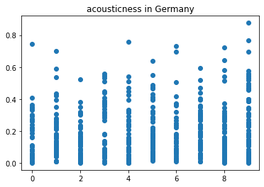

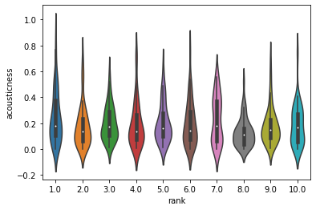

```python
plot(germany_df_final, "acousticness in Germany","acousticness")
sns.violinplot(x= "rank", y = "acousticness", data = germany_df_final)
```

acousticness measures whether a song was played without the assistance of electronics. Comparing Germany and the US, we can see the US is slighty more variable with it's acoustiness, but not by much.Both data sets are skewed towards the bottom, with lower acousticness. Overall, I would say this indicates that most music nowadays has some level of electronic component to it.

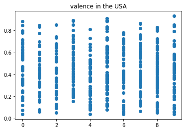

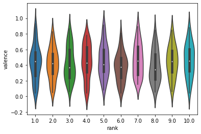

```python
#comparing valence in USA and Germany
plot(america_df_final, "valence in the USA","valence")
sns.violinplot(x= "rank", y = "valence", data = america_df_final)
```